# 100 most powerful women(1)

### ANALYSIS OF THE 100 MOST POWERFUL WOMEN IN THE WORLD 2022 RANKINGS

### CONTENTS

- [x] Introduction
- [x] Libraries imports
- [x] Data exploration
- [x] Data cleaning
- [x] Data analysis
- [x] Data visualization
- [x] Conclusion and Findings

#### IINTRODUCTION

Power is the ability to influence the behavior of others with or without resistance. Power is the ability to get things done. People with power are able to influence others behavior to achieve a goal or objective. Influence occurs when a person’s emotions, opinions, or behaviors are affected by others. It is an important component of a leader’s ability to use power and maintain respect in an organization or a nation.

A powerful woman is a woman who is not afraid to share her ideas and thoughts, regardless of what others think. She speaks her heart and her mind, she respects herself enough to stand up for herself, believes in herself, and for the welfare of others.

#### ABOUT THE DATA

The data is originally from https://www.forbes.com/lists/power-women but my dataset was downloaded from https://www.kaggle.com/datasets/devrimtuner/the-worlds-100-most-powerful-women, as a CSV file. The data shows their ranks in the world most powerful women, shows their age and country. The dataset is reliable, original and comprehensive. The source has their own licence over the dataset. All the files have consistent columns. Finally, It would be good to have some updated information about the age of some of the women in the dataset, because I had to do some research in order to find the particular age of some of the women in the dataset which was intially stored with an `hyphen sign '-'`. The dataset was determined by four main metrics: money, media, impact and spheres of influence. For political leaders, it weighed gross domestic products and populations; for corporate leaders, revenues and employee counts; and media mentions and reach of all. The result is a collection of women who are fighting the status quo.

#### QUESTION(S) FOR MY ANALYSIS ON THE TOP 100 MOST POWERFUL WOMEN IN THE WORLD

The following are a list of questions to be answered after carefully studying the dataset:

- Top 10 most powerful women by their rank
- Most powerful women in politics, business, finance, philanthropy, wealth management, singing & songwriting, diplomacy, venture capital, media & entertainment
- Total number of powerful women in each category
- The country with the most powerful women
- The most powerful women from North America
- The most powerful women from Africa
- The most powerful women from Asia
- The most powerful women from Europe
- The most powerful women from Australia
- The continent with the most powerful women
- Most powerful women under the age of 50
- Youngest most powerful woman

#### IMPORT THE LIBRARY

```python
# Libraries import
import pandas as pd
import numpy as np
import seaborn as sns
import matplotlib.pyplot as plt
```

#### LOAD MY DATASET

```python
#loading my data set
df = pd.read_csv("worlds_100_Powerful_women.csv")
```

```python
df.head()
```

|  | RANK | NAME | AGE | LOCATION | CATEGORY |
| --- | --- | --- | --- | --- | --- |
| 0 | 1.0 | Ursula von der Leyen | 64 | Belgium | Politics & Policy |
| 1 | 2.0 | Christine Lagarde | 66 | Germany | Politics & Policy |
| 2 | 3.0 | Kamala Harris | 58 | United States | Politics & Policy |
| 3 | 4.0 | Mary Barra | 60 | United States | Business |
| 4 | 5.0 | Abigail Johnson | 60 | United States | Money |

```python
df.tail()
```

|  | RANK | NAME | AGE | LOCATION | CATEGORY |
| --- | --- | --- | --- | --- | --- |
| 95 | 96.0 | Dolly Parton | 76 | United States | Lifestyle |
| 96 | 97.0 | Kirsten Green | 51 | United States | Money |
| 97 | 98.0 | Mia Mottley | 57 | Barbados | Politics & Policy |
| 98 | 99.0 | Mo Abudu | 58 | Nigeria | Media & Entertainment |
| 99 | 100.0 | Mahsa Amini (posthumous) | - | Iran | Politics & Policy |

#### EXPLORING MY DATASET

```python
#Now let's explore the datset
```

```python
#checking the shape of the dataframe
df.shape
```

```
(100, 5)
```

```python
#Basic info about the DataFrame
df.info()
```

```
<class 'pandas.core.frame.DataFrame'>
RangeIndex: 100 entries, 0 to 99
Data columns (total 5 columns):
 #   Column    Non-Null Count  Dtype
---  ------    --------------  -----
 0   RANK      100 non-null    float64
 1   NAME      100 non-null    object
 2   AGE       100 non-null    object
 3   LOCATION  100 non-null    object
 4   CATEGORY  100 non-null    object
dtypes: float64(1), object(4)
memory usage: 4.0+ KB
```

```python
#Checking for duplicates
df.duplicated().sum()
```

```
0
```

```python
#Checking for null values
df.isnull().any()
```

```
RANK        False
NAME        False
AGE         False
LOCATION    False
CATEGORY    False
dtype: bool
```

```python
#checking for null values
df.isnull().sum()
```

```
RANK        0
NAME        0
AGE         0
LOCATION    0
CATEGORY    0
dtype: int64
```

```python
# Using isna() to cross check the entire dataset for null or missing values
df.isna()
```

|  | RANK | NAME | AGE | LOCATION | CATEGORY |
| --- | --- | --- | --- | --- | --- |
| 0 | False | False | False | False | False |
| 1 | False | False | False | False | False |
| 2 | False | False | False | False | False |
| 3 | False | False | False | False | False |
| 4 | False | False | False | False | False |
| ... | ... | ... | ... | ... | ... |
| 95 | False | False | False | False | False |
| 96 | False | False | False | False | False |
| 97 | False | False | False | False | False |
| 98 | False | False | False | False | False |
| 99 | False | False | False | False | False |

100 rows × 5 columns

#### DATA CLEANING

After going through the data provided in the dataset, I found out that some informations in the data of the `Category column` are not accurate and some data for the `Age column` has the `hyphen sign '-'` inputted for the age value instead of their age. The accurate informations on some of these data can be gotten from wikipedia where you can find their personal profiles and information including age and their occupation and some other informations on age can be gotten from some reliable websites.

- I will be inputting the accurate data on some of the categories of our most powerful women
- Filling up the age values that has the hyphen sign `'-'` with their appropriate age
- Inputting the accurate country information on Christine Lagarde's data on the `location column`
- I will be inputting a new column for `Continents` that this powerful women are from. This will help our analysis on the continent with the most powerful women.
1. Inputting accurate information on some of the data values in our `Category column`
- I will start by updating for Abigail Johnson's category column

```python
# Changing Abigail Johnson category column
df.loc[4]
```

```
RANK                    5.0
NAME        Abigail Johnson
AGE                      60
LOCATION      United States
CATEGORY              Money
Name: 4, dtype: object
```

```python
# Note Abigail Johnson is into business
df.loc[4] = ['5.0','Abigail Johnson','60','United States','Business']
df
```

|  | RANK | NAME | AGE | LOCATION | CATEGORY |
| --- | --- | --- | --- | --- | --- |
| 0 | 1.0 | Ursula von der Leyen | 64 | Belgium | Politics & Policy |
| 1 | 2.0 | Christine Lagarde | 66 | Germany | Politics & Policy |
| 2 | 3.0 | Kamala Harris | 58 | United States | Politics & Policy |
| 3 | 4.0 | Mary Barra | 60 | United States | Business |
| 4 | 5.0 | Abigail Johnson | 60 | United States | Business |
| ... | ... | ... | ... | ... | ... |
| 95 | 96.0 | Dolly Parton | 76 | United States | Lifestyle |
| 96 | 97.0 | Kirsten Green | 51 | United States | Money |
| 97 | 98.0 | Mia Mottley | 57 | Barbados | Politics & Policy |
| 98 | 99.0 | Mo Abudu | 58 | Nigeria | Media & Entertainment |
| 99 | 100.0 | Mahsa Amini (posthumous) | - | Iran | Politics & Policy |

100 rows × 5 columns

- updating category column for MacKenzie Scott

```python
# Changing MacKenzie Scott category column
df.loc[10]
```

```
RANK                   11.0
NAME        MacKenzie Scott
AGE                      52
LOCATION      United States
CATEGORY             Impact
Name: 10, dtype: object
```

```python
#  MacKenzie Scott is into philanthropy
df.loc[10] = ['11.0','MacKenzie Scott','52','United States','Philanthropy']
df
```

|  | RANK | NAME | AGE | LOCATION | CATEGORY |
| --- | --- | --- | --- | --- | --- |
| 0 | 1.0 | Ursula von der Leyen | 64 | Belgium | Politics & Policy |
| 1 | 2.0 | Christine Lagarde | 66 | Germany | Politics & Policy |
| 2 | 3.0 | Kamala Harris | 58 | United States | Politics & Policy |
| 3 | 4.0 | Mary Barra | 60 | United States | Business |
| 4 | 5.0 | Abigail Johnson | 60 | United States | Business |
| ... | ... | ... | ... | ... | ... |
| 95 | 96.0 | Dolly Parton | 76 | United States | Lifestyle |
| 96 | 97.0 | Kirsten Green | 51 | United States | Money |
| 97 | 98.0 | Mia Mottley | 57 | Barbados | Politics & Policy |
| 98 | 99.0 | Mo Abudu | 58 | Nigeria | Media & Entertainment |
| 99 | 100.0 | Mahsa Amini (posthumous) | - | Iran | Politics & Policy |

100 rows × 5 columns

- updating category column for Shari Redstone

```python
# Changing Shari Redstone's category column
df.loc[31]
```

```
RANK                  32.0
NAME        Shari Redstone
AGE                     68
LOCATION     United States
CATEGORY         Lifestyle
Name: 31, dtype: object
```

```python
# Shari Redstone is into media and entertainment
df.loc[31] = ['32.0','Shari Redstone','68','United States','Media & Entertainment']
df
```

|  | RANK | NAME | AGE | LOCATION | CATEGORY |
| --- | --- | --- | --- | --- | --- |
| 0 | 1.0 | Ursula von der Leyen | 64 | Belgium | Politics & Policy |
| 1 | 2.0 | Christine Lagarde | 66 | Germany | Politics & Policy |
| 2 | 3.0 | Kamala Harris | 58 | United States | Politics & Policy |
| 3 | 4.0 | Mary Barra | 60 | United States | Business |
| 4 | 5.0 | Abigail Johnson | 60 | United States | Business |
| ... | ... | ... | ... | ... | ... |
| 95 | 96.0 | Dolly Parton | 76 | United States | Lifestyle |
| 96 | 97.0 | Kirsten Green | 51 | United States | Money |
| 97 | 98.0 | Mia Mottley | 57 | Barbados | Politics & Policy |
| 98 | 99.0 | Mo Abudu | 58 | Nigeria | Media & Entertainment |
| 99 | 100.0 | Mahsa Amini (posthumous) | - | Iran | Politics & Policy |

100 rows × 5 columns

- updating category column for Mary Callahan Erdoes

```python
# Changing Mary Callahan Erdoes's category column
df.loc[42]
```

```
RANK                        43.0
NAME        Mary Callahan Erdoes
AGE                           55
LOCATION           United States
CATEGORY                   Money
Name: 42, dtype: object
```

```python
# Mary Callahan Erdoes is into wealth mangement
df.loc[42] = ['43.0','Mary Callahan Erdoes','55','United States','Wealth Management']
df
```

|  | RANK | NAME | AGE | LOCATION | CATEGORY |
| --- | --- | --- | --- | --- | --- |
| 0 | 1.0 | Ursula von der Leyen | 64 | Belgium | Politics & Policy |
| 1 | 2.0 | Christine Lagarde | 66 | Germany | Politics & Policy |
| 2 | 3.0 | Kamala Harris | 58 | United States | Politics & Policy |
| 3 | 4.0 | Mary Barra | 60 | United States | Business |
| 4 | 5.0 | Abigail Johnson | 60 | United States | Business |
| ... | ... | ... | ... | ... | ... |
| 95 | 96.0 | Dolly Parton | 76 | United States | Lifestyle |
| 96 | 97.0 | Kirsten Green | 51 | United States | Money |
| 97 | 98.0 | Mia Mottley | 57 | Barbados | Politics & Policy |
| 98 | 99.0 | Mo Abudu | 58 | Nigeria | Media & Entertainment |
| 99 | 100.0 | Mahsa Amini (posthumous) | - | Iran | Politics & Policy |

100 rows × 5 columns

- updating category column for Jenny Johnson

```python
# Changing Jenny Johnson's category column
df.loc[58]
```

```
RANK                 59.0
NAME        Jenny Johnson
AGE                    58
LOCATION    United States
CATEGORY            Money
Name: 58, dtype: object
```

```python
#  Jenny Johnson is into business
df.loc[58] = ['59.0','Jenny Johnson','58','United States','Business']
df
```

|  | RANK | NAME | AGE | LOCATION | CATEGORY |
| --- | --- | --- | --- | --- | --- |
| 0 | 1.0 | Ursula von der Leyen | 64 | Belgium | Politics & Policy |
| 1 | 2.0 | Christine Lagarde | 66 | Germany | Politics & Policy |
| 2 | 3.0 | Kamala Harris | 58 | United States | Politics & Policy |
| 3 | 4.0 | Mary Barra | 60 | United States | Business |
| 4 | 5.0 | Abigail Johnson | 60 | United States | Business |
| ... | ... | ... | ... | ... | ... |
| 95 | 96.0 | Dolly Parton | 76 | United States | Lifestyle |
| 96 | 97.0 | Kirsten Green | 51 | United States | Money |
| 97 | 98.0 | Mia Mottley | 57 | Barbados | Politics & Policy |
| 98 | 99.0 | Mo Abudu | 58 | Nigeria | Media & Entertainment |
| 99 | 100.0 | Mahsa Amini (posthumous) | - | Iran | Politics & Policy |

100 rows × 5 columns

- updating category column for Linda Thomas-Greenfield

```python
# Changing Linda Thomas-Greenfield's category column
df.loc[81]
```

```
RANK                           82.0
NAME        Linda Thomas-Greenfield
AGE                              70
LOCATION              United States
CATEGORY                     Impact
Name: 81, dtype: object
```

```python
# Linda Thomas-Greenfield is into diplomacy
df.loc[81] = ['82.0','Linda Thomas-Greenfield','70','United States','Diplomat']
df
```

|  | RANK | NAME | AGE | LOCATION | CATEGORY |
| --- | --- | --- | --- | --- | --- |
| 0 | 1.0 | Ursula von der Leyen | 64 | Belgium | Politics & Policy |
| 1 | 2.0 | Christine Lagarde | 66 | Germany | Politics & Policy |
| 2 | 3.0 | Kamala Harris | 58 | United States | Politics & Policy |
| 3 | 4.0 | Mary Barra | 60 | United States | Business |
| 4 | 5.0 | Abigail Johnson | 60 | United States | Business |
| ... | ... | ... | ... | ... | ... |
| 95 | 96.0 | Dolly Parton | 76 | United States | Lifestyle |
| 96 | 97.0 | Kirsten Green | 51 | United States | Money |
| 97 | 98.0 | Mia Mottley | 57 | Barbados | Politics & Policy |
| 98 | 99.0 | Mo Abudu | 58 | Nigeria | Media & Entertainment |
| 99 | 100.0 | Mahsa Amini (posthumous) | - | Iran | Politics & Policy |

100 rows × 5 columns

- updating category column for Shonda Rhimes

```python
# Changing Shonda Rhimes's category column
df.loc[92]
```

```
RANK                 93.0
NAME        Shonda Rhimes
AGE                    52
LOCATION    United States
CATEGORY    Entertainment
Name: 92, dtype: object
```

```python
# Shonda Rhimes is into media and entertainment
df.loc[92] = ['93.0','Shonda Rhimes','52','United States','Media & Entertainment']
df
```

|  | RANK | NAME | AGE | LOCATION | CATEGORY |
| --- | --- | --- | --- | --- | --- |
| 0 | 1.0 | Ursula von der Leyen | 64 | Belgium | Politics & Policy |
| 1 | 2.0 | Christine Lagarde | 66 | Germany | Politics & Policy |
| 2 | 3.0 | Kamala Harris | 58 | United States | Politics & Policy |
| 3 | 4.0 | Mary Barra | 60 | United States | Business |
| 4 | 5.0 | Abigail Johnson | 60 | United States | Business |
| ... | ... | ... | ... | ... | ... |
| 95 | 96.0 | Dolly Parton | 76 | United States | Lifestyle |
| 96 | 97.0 | Kirsten Green | 51 | United States | Money |
| 97 | 98.0 | Mia Mottley | 57 | Barbados | Politics & Policy |
| 98 | 99.0 | Mo Abudu | 58 | Nigeria | Media & Entertainment |
| 99 | 100.0 | Mahsa Amini (posthumous) | - | Iran | Politics & Policy |

100 rows × 5 columns

- updating category column for Dolly Parton

```python
# Changing Dolly Parton's category column
df.loc[95]
```

```
RANK                 96.0
NAME         Dolly Parton
AGE                    76
LOCATION    United States
CATEGORY        Lifestyle
Name: 95, dtype: object
```

```python
# Dolly Parton is into singing and songwriting
df.loc[95] = ['96.0','Dolly Parton','76','United States','Singer-songwriter']
df
```

|  | RANK | NAME | AGE | LOCATION | CATEGORY |
| --- | --- | --- | --- | --- | --- |
| 0 | 1.0 | Ursula von der Leyen | 64 | Belgium | Politics & Policy |
| 1 | 2.0 | Christine Lagarde | 66 | Germany | Politics & Policy |
| 2 | 3.0 | Kamala Harris | 58 | United States | Politics & Policy |
| 3 | 4.0 | Mary Barra | 60 | United States | Business |
| 4 | 5.0 | Abigail Johnson | 60 | United States | Business |
| ... | ... | ... | ... | ... | ... |
| 95 | 96.0 | Dolly Parton | 76 | United States | Singer-songwriter |
| 96 | 97.0 | Kirsten Green | 51 | United States | Money |
| 97 | 98.0 | Mia Mottley | 57 | Barbados | Politics & Policy |
| 98 | 99.0 | Mo Abudu | 58 | Nigeria | Media & Entertainment |
| 99 | 100.0 | Mahsa Amini (posthumous) | - | Iran | Politics & Policy |

100 rows × 5 columns

- updating category column for Kirsten Green

```python
# Changing Kirsten Green's category column
df.loc[96]
```

```
RANK                 97.0
NAME        Kirsten Green
AGE                    51
LOCATION    United States
CATEGORY            Money
Name: 96, dtype: object
```

```python
# Kirsten Green is into venture capitals
df.loc[96] = ['97.0','Kirsten Green','51','United States','Venture Capital']
df
```

|  | RANK | NAME | AGE | LOCATION | CATEGORY |
| --- | --- | --- | --- | --- | --- |
| 0 | 1.0 | Ursula von der Leyen | 64 | Belgium | Politics & Policy |
| 1 | 2.0 | Christine Lagarde | 66 | Germany | Politics & Policy |
| 2 | 3.0 | Kamala Harris | 58 | United States | Politics & Policy |
| 3 | 4.0 | Mary Barra | 60 | United States | Business |
| 4 | 5.0 | Abigail Johnson | 60 | United States | Business |
| ... | ... | ... | ... | ... | ... |
| 95 | 96.0 | Dolly Parton | 76 | United States | Singer-songwriter |
| 96 | 97.0 | Kirsten Green | 51 | United States | Venture Capital |
| 97 | 98.0 | Mia Mottley | 57 | Barbados | Politics & Policy |
| 98 | 99.0 | Mo Abudu | 58 | Nigeria | Media & Entertainment |
| 99 | 100.0 | Mahsa Amini (posthumous) | - | Iran | Politics & Policy |

100 rows × 5 columns

A preview of the updated dataset

```python
# Preview of the updated dataset with the first 40 rows
df.head(40)
```

|  | RANK | NAME | AGE | LOCATION | CATEGORY |
| --- | --- | --- | --- | --- | --- |
| 0 | 1.0 | Ursula von der Leyen | 64 | Belgium | Politics & Policy |
| 1 | 2.0 | Christine Lagarde | 66 | Germany | Politics & Policy |
| 2 | 3.0 | Kamala Harris | 58 | United States | Politics & Policy |
| 3 | 4.0 | Mary Barra | 60 | United States | Business |
| 4 | 5.0 | Abigail Johnson | 60 | United States | Business |
| 5 | 6.0 | Melinda French Gates | 58 | United States | Philanthropy |
| 6 | 7.0 | Giorgia Meloni | 45 | Italy | Politics & Policy |
| 7 | 8.0 | Karen Lynch | 58 | United States | Business |
| 8 | 9.0 | Julie Sweet | 55 | United States | Business |
| 9 | 10.0 | Jane Fraser | 55 | United States | Finance |
| 10 | 11.0 | MacKenzie Scott | 52 | United States | Philanthropy |
| 11 | 12.0 | Kristalina Georgieva | 69 | United States | Politics & Policy |
| 12 | 13.0 | Rosalind Brewer | 59 | United States | Business |
| 13 | 14.0 | Emma Walmsley | 53 | United Kingdom | Business |
| 14 | 15.0 | Ana Patricia Botín | 62 | Spain | Finance |
| 15 | 16.0 | Gail Boudreaux | 62 | United States | Business |
| 16 | 17.0 | Tsai Ing-wen | 66 | Taiwan | Politics & Policy |
| 17 | 18.0 | Ruth Porat | 65 | United States | Technology |
| 18 | 19.0 | Safra Catz | 60 | United States | Technology |
| 19 | 20.0 | Martina Merz | 59 | Germany | Business |
| 20 | 21.0 | Carol Tomé | 65 | United States | Business |
| 21 | 22.0 | Judith McKenna | 56 | United States | Business |
| 22 | 23.0 | Susan Wojcicki | 54 | United States | Technology |
| 23 | 24.0 | Oprah Winfrey | 68 | United States | Media & Entertainment |
| 24 | 25.0 | Nancy Pelosi | 82 | United States | Politics & Policy |
| 25 | 26.0 | Laurene Powell Jobs & family | 59 | United States | Philanthropy |
| 26 | 27.0 | Amanda Blanc | 55 | United Kingdom | Business |
| 27 | 28.0 | Amy Hood | 50 | United States | Technology |
| 28 | 29.0 | Catherine MacGregor | 50 | France | Business |
| 29 | 30.0 | Phebe Novakovic | 65 | United States | Entrepreneurs |
| 30 | 31.0 | Gwynne Shotwell | 59 | United States | Technology |
| 31 | 32.0 | Shari Redstone | 68 | United States | Media & Entertainment |
| 32 | 33.0 | Janet Yellen | 76 | United States | Politics & Policy |
| 33 | 34.0 | Jessica Tan | 45 | China | Finance |
| 34 | 35.0 | Ho Ching | 69 | Singapore | Finance |
| 35 | 36.0 | Nirmala Sitharaman | 63 | India | Politics & Policy |
| 36 | 37.0 | Thasunda Brown Duckett | 49 | United States | Finance |
| 37 | 38.0 | Kathy Warden | 51 | United States | Business |
| 38 | 39.0 | Marianne Lake, Jennifer Piepszak | - | United States | Finance |
| 39 | 40.0 | Jacinda Ardern | 42 | New Zealand | Politics & Policy |

```python
# Bottom 20 preview of the updated dataset
df.tail(20)
```

|  | RANK | NAME | AGE | LOCATION | CATEGORY |
| --- | --- | --- | --- | --- | --- |
| 80 | 81.0 | Güler Sabanci | 67 | Turkey | Business |
| 81 | 82.0 | Linda Thomas-Greenfield | 70 | United States | Diplomat |
| 82 | 83.0 | Sanna Marin | 37 | Finland | Politics & Policy |
| 83 | 84.0 | Solina Chau | 60 | China | Philanthropy |
| 84 | 85.0 | Lee Boo-jin | 52 | South Korea | Business |
| 85 | 86.0 | Reese Witherspoon | 46 | United States | Media & Entertainment |
| 86 | 87.0 | Zuzana Caputova | 49 | Slovakia | Politics & Policy |
| 87 | 88.0 | Dominique Senequier | 69 | France | Finance |
| 88 | 89.0 | Falguni Nayar | 59 | India | Business |
| 89 | 90.0 | Julia Gillard | 61 | Australia | Philanthropy |
| 90 | 91.0 | Ngozi Okonjo-Iweala | 68 | Nigeria | Politics & Policy |
| 91 | 92.0 | Raja Easa Al Gurg | - | United Arab Emirates | Business |
| 92 | 93.0 | Shonda Rhimes | 52 | United States | Media & Entertainment |
| 93 | 94.0 | Xiomara Castro | 63 | Honduras | Politics & Policy |
| 94 | 95.0 | Samia Suluhu Hassan | 62 | Tanzania | Politics & Policy |
| 95 | 96.0 | Dolly Parton | 76 | United States | Singer-songwriter |
| 96 | 97.0 | Kirsten Green | 51 | United States | Venture Capital |
| 97 | 98.0 | Mia Mottley | 57 | Barbados | Politics & Policy |
| 98 | 99.0 | Mo Abudu | 58 | Nigeria | Media & Entertainment |
| 99 | 100.0 | Mahsa Amini (posthumous) | - | Iran | Politics & Policy |

1. Filling up the various age values that has the hyphen sign `'-'` with their appropriate age values. The various websites we got their ages from will be written on their code blocks.

```python
# Updating the 'Age" value for Marianne Lake and Jennifer Piepszak
# Age gotten from: (https://en.wikipedia.org/wiki/Marianne_Lake)
# Age gotten from: (https://www.barrons.com/articles/barrons-100-most-influential-women-in-u-s-finance-jennifer-piepszak-5165061442)
df.loc[38]
```

```
RANK                                    39.0
NAME        Marianne Lake, Jennifer Piepszak
AGE                                        -
LOCATION                       United States
CATEGORY                             Finance
Name: 38, dtype: object
```

I noticed that this cell has more than one profile name. Note that these two profiles where `ranked` at the same position that is the reason for the two profiles showing on the same position. Jennifer Piepszak's age `(52_years)` will be fixed to her name, while Marianne Lake's age `(54_years)` will be left on the age column, so that it won't affect my analysis on age later. I will be looking for powerful women who are less than 50 years of age later in my analysis. That means her age will not affect the analysis when analyzing ages below 50.

```python
# Updating age data for Marianne Lake and Jennifer Piepszak.
# I fixed Jennifer Piepszak age (52_years) to her name so that it won't affect my analysis on powerful women under the age of 50 later
df.loc[38] = ['39.0','Marianne Lake, Jennifer Piepszak(52_years)','54','United States','Finance']
df
```

|  | RANK | NAME | AGE | LOCATION | CATEGORY |
| --- | --- | --- | --- | --- | --- |
| 0 | 1.0 | Ursula von der Leyen | 64 | Belgium | Politics & Policy |
| 1 | 2.0 | Christine Lagarde | 66 | Germany | Politics & Policy |
| 2 | 3.0 | Kamala Harris | 58 | United States | Politics & Policy |
| 3 | 4.0 | Mary Barra | 60 | United States | Business |
| 4 | 5.0 | Abigail Johnson | 60 | United States | Business |
| ... | ... | ... | ... | ... | ... |
| 95 | 96.0 | Dolly Parton | 76 | United States | Singer-songwriter |
| 96 | 97.0 | Kirsten Green | 51 | United States | Venture Capital |
| 97 | 98.0 | Mia Mottley | 57 | Barbados | Politics & Policy |
| 98 | 99.0 | Mo Abudu | 58 | Nigeria | Media & Entertainment |
| 99 | 100.0 | Mahsa Amini (posthumous) | - | Iran | Politics & Policy |

100 rows × 5 columns

```python
# Updating the 'Age" data for Paula Santilli.
# Age gotten from: (https://app.boardroomalpha.com/profiles/people/A1176721-PAULA_SANTILLI)
df.loc[70]
```

```
RANK                  71.0
NAME        Paula Santilli
AGE                      -
LOCATION            Mexico
CATEGORY          Business
Name: 70, dtype: object
```

```python
# Updating the age data for Paula Santilli
df.loc[70] = ['71.0','Paula Santilli','57','Mexico','Business']
df
```

|  | RANK | NAME | AGE | LOCATION | CATEGORY |
| --- | --- | --- | --- | --- | --- |
| 0 | 1.0 | Ursula von der Leyen | 64 | Belgium | Politics & Policy |
| 1 | 2.0 | Christine Lagarde | 66 | Germany | Politics & Policy |
| 2 | 3.0 | Kamala Harris | 58 | United States | Politics & Policy |
| 3 | 4.0 | Mary Barra | 60 | United States | Business |
| 4 | 5.0 | Abigail Johnson | 60 | United States | Business |
| ... | ... | ... | ... | ... | ... |
| 95 | 96.0 | Dolly Parton | 76 | United States | Singer-songwriter |
| 96 | 97.0 | Kirsten Green | 51 | United States | Venture Capital |
| 97 | 98.0 | Mia Mottley | 57 | Barbados | Politics & Policy |
| 98 | 99.0 | Mo Abudu | 58 | Nigeria | Media & Entertainment |
| 99 | 100.0 | Mahsa Amini (posthumous) | - | Iran | Politics & Policy |

100 rows × 5 columns

```python
# Updating the 'Age" data for Laura Cha.
# Age gotten from: (https://en.wikipedia.org/wiki/Laura_Cha)
df.loc[71]
```

```
RANK             72.0
NAME        Laura Cha
AGE                 -
LOCATION        China
CATEGORY      Finance
Name: 71, dtype: object
```

```python
# Updating the age data for Laura Cha
df.loc[71] = ['72.0','Laura Cha','73','China','Finance']
df
```

|  | RANK | NAME | AGE | LOCATION | CATEGORY |
| --- | --- | --- | --- | --- | --- |
| 0 | 1.0 | Ursula von der Leyen | 64 | Belgium | Politics & Policy |
| 1 | 2.0 | Christine Lagarde | 66 | Germany | Politics & Policy |
| 2 | 3.0 | Kamala Harris | 58 | United States | Politics & Policy |
| 3 | 4.0 | Mary Barra | 60 | United States | Business |
| 4 | 5.0 | Abigail Johnson | 60 | United States | Business |
| ... | ... | ... | ... | ... | ... |
| 95 | 96.0 | Dolly Parton | 76 | United States | Singer-songwriter |
| 96 | 97.0 | Kirsten Green | 51 | United States | Venture Capital |
| 97 | 98.0 | Mia Mottley | 57 | Barbados | Politics & Policy |
| 98 | 99.0 | Mo Abudu | 58 | Nigeria | Media & Entertainment |
| 99 | 100.0 | Mahsa Amini (posthumous) | - | Iran | Politics & Policy |

100 rows × 5 columns

```python
# Updating the 'Age" data for Raja Easa Al Gurg.
# Age gotten from: (https://www.thenationalnews.com/arts-culture/books/raja-al-gurg-in-life-and-business-uae-women-can-have-it-all-1.805368)
# According to the website Raja Easa Al Gurg was born in November 5, 1955, that's approximately 67 years old.
df.loc[91]
```

```
RANK                        92.0
NAME           Raja Easa Al Gurg
AGE                            -
LOCATION    United Arab Emirates
CATEGORY                Business
Name: 91, dtype: object
```

```python
# Updating the age data for Raja Easa Al Gurg
df.loc[91] = ['92.0','Raja Easa Al Gurg','67','United Arab Emirates','Business']
df
```

|  | RANK | NAME | AGE | LOCATION | CATEGORY |
| --- | --- | --- | --- | --- | --- |
| 0 | 1.0 | Ursula von der Leyen | 64 | Belgium | Politics & Policy |
| 1 | 2.0 | Christine Lagarde | 66 | Germany | Politics & Policy |
| 2 | 3.0 | Kamala Harris | 58 | United States | Politics & Policy |
| 3 | 4.0 | Mary Barra | 60 | United States | Business |
| 4 | 5.0 | Abigail Johnson | 60 | United States | Business |
| ... | ... | ... | ... | ... | ... |
| 95 | 96.0 | Dolly Parton | 76 | United States | Singer-songwriter |
| 96 | 97.0 | Kirsten Green | 51 | United States | Venture Capital |
| 97 | 98.0 | Mia Mottley | 57 | Barbados | Politics & Policy |
| 98 | 99.0 | Mo Abudu | 58 | Nigeria | Media & Entertainment |
| 99 | 100.0 | Mahsa Amini (posthumous) | - | Iran | Politics & Policy |

100 rows × 5 columns

```python
# Updating the 'Age" data for Mahsa Amini (posthumous).
# Age gotten from: (https://en.wikipedia.org/wiki/Death_of_Mahsa_Amini)
df.loc[99]
```

```
RANK                           100.0
NAME        Mahsa Amini (posthumous)
AGE                                -
LOCATION                        Iran
CATEGORY           Politics & Policy
Name: 99, dtype: object
```

```python
# Updating the age data for Mahsa Amini (posthumous)
df.loc[99] = ['100.0','Mahsa Amini (posthumous)','22','Iran','Politics & Policy']
df
```

|  | RANK | NAME | AGE | LOCATION | CATEGORY |
| --- | --- | --- | --- | --- | --- |
| 0 | 1.0 | Ursula von der Leyen | 64 | Belgium | Politics & Policy |
| 1 | 2.0 | Christine Lagarde | 66 | Germany | Politics & Policy |
| 2 | 3.0 | Kamala Harris | 58 | United States | Politics & Policy |
| 3 | 4.0 | Mary Barra | 60 | United States | Business |
| 4 | 5.0 | Abigail Johnson | 60 | United States | Business |
| ... | ... | ... | ... | ... | ... |
| 95 | 96.0 | Dolly Parton | 76 | United States | Singer-songwriter |
| 96 | 97.0 | Kirsten Green | 51 | United States | Venture Capital |
| 97 | 98.0 | Mia Mottley | 57 | Barbados | Politics & Policy |
| 98 | 99.0 | Mo Abudu | 58 | Nigeria | Media & Entertainment |
| 99 | 100.0 | Mahsa Amini (posthumous) | 22 | Iran | Politics & Policy |

100 rows × 5 columns

```python
# I couldn't find the age for Hana Al Rostamani after a thorough research on her age
# So I am going to remove the hyphen sign '-' and leave it blank so it won't distrupt my analysis on age later
df.loc[59]
```

```
RANK                        60.0
NAME           Hana Al Rostamani
AGE                            -
LOCATION    United Arab Emirates
CATEGORY                 Finance
Name: 59, dtype: object
```

```python
# I will remove the hyphen sign '-' for Hana Al Rostamani and also leave the age blank so it won't affect my analysis for age later
df.loc[59] = ['60.0','Hana Al Rostamani','','United Arab Emirates','Finance']
df
```

|  | RANK | NAME | AGE | LOCATION | CATEGORY |
| --- | --- | --- | --- | --- | --- |
| 0 | 1.0 | Ursula von der Leyen | 64 | Belgium | Politics & Policy |
| 1 | 2.0 | Christine Lagarde | 66 | Germany | Politics & Policy |
| 2 | 3.0 | Kamala Harris | 58 | United States | Politics & Policy |
| 3 | 4.0 | Mary Barra | 60 | United States | Business |
| 4 | 5.0 | Abigail Johnson | 60 | United States | Business |
| ... | ... | ... | ... | ... | ... |
| 95 | 96.0 | Dolly Parton | 76 | United States | Singer-songwriter |
| 96 | 97.0 | Kirsten Green | 51 | United States | Venture Capital |
| 97 | 98.0 | Mia Mottley | 57 | Barbados | Politics & Policy |
| 98 | 99.0 | Mo Abudu | 58 | Nigeria | Media & Entertainment |
| 99 | 100.0 | Mahsa Amini (posthumous) | 22 | Iran | Politics & Policy |

100 rows × 5 columns

1. Inputting the accurate country information on Christine Lagarde's data on the location column

```python
# updating Christine Lagarde's location info
df.loc[1]
```

```
RANK                      2.0
NAME        Christine Lagarde
AGE                        66
LOCATION              Germany
CATEGORY    Politics & Policy
Name: 1, dtype: object
```

```python
# Christine Lagarde is a French politician and the current President of the European Central Bank
# She is from France and the information about her nationality can be gotten from:(https://en.wikipedia.org/wiki/Christine_Lagarde)
df.loc[1] = ['2.0','Christine Lagarde','66','France','Politics & Policy']
df
```

|  | RANK | NAME | AGE | LOCATION | CATEGORY |
| --- | --- | --- | --- | --- | --- |
| 0 | 1.0 | Ursula von der Leyen | 64 | Belgium | Politics & Policy |
| 1 | 2.0 | Christine Lagarde | 66 | France | Politics & Policy |
| 2 | 3.0 | Kamala Harris | 58 | United States | Politics & Policy |
| 3 | 4.0 | Mary Barra | 60 | United States | Business |
| 4 | 5.0 | Abigail Johnson | 60 | United States | Business |
| ... | ... | ... | ... | ... | ... |
| 95 | 96.0 | Dolly Parton | 76 | United States | Singer-songwriter |
| 96 | 97.0 | Kirsten Green | 51 | United States | Venture Capital |
| 97 | 98.0 | Mia Mottley | 57 | Barbados | Politics & Policy |
| 98 | 99.0 | Mo Abudu | 58 | Nigeria | Media & Entertainment |
| 99 | 100.0 | Mahsa Amini (posthumous) | 22 | Iran | Politics & Policy |

100 rows × 5 columns

1. Inputting a new column for Continents that this powerful women are from. This will help our analysis on the continent with the most powerful women

To add the new `Continent` column to the existing dataframe I will be uploading another CSV file containing only their various continents which I updated using excel, then I will concatenate the new file and the existing dataframe. This will help me save time instead of creating a column and inputting their continents one after each other, because I have over 100 rows to fill with their various continents.

```python
#load the continent dataset
df1 = pd.read_csv("continents_powerful women.csv")
```

```python
# The data for the continents where our top 100 most powerful women came from
df1.head()
```

|  | CONTINENT |
| --- | --- |
| 0 | Europe |
| 1 | Europe |
| 2 | North America |
| 3 | North America |
| 4 | North America |

```python
# My previous cleaned/updated data which i will be concatenating with their continents data
df.head()
```

|  | RANK | NAME | AGE | LOCATION | CATEGORY |
| --- | --- | --- | --- | --- | --- |
| 0 | 1.0 | Ursula von der Leyen | 64 | Belgium | Politics & Policy |
| 1 | 2.0 | Christine Lagarde | 66 | France | Politics & Policy |
| 2 | 3.0 | Kamala Harris | 58 | United States | Politics & Policy |
| 3 | 4.0 | Mary Barra | 60 | United States | Business |
| 4 | 5.0 | Abigail Johnson | 60 | United States | Business |

```python
# Concatenating the continents data with the cleaned data to give us the updated dataset with their various continents
df_updated = pd.concat([df, df1], axis=1)
```

```python
df_updated
```

|  | RANK | NAME | AGE | LOCATION | CATEGORY | CONTINENT |
| --- | --- | --- | --- | --- | --- | --- |
| 0 | 1.0 | Ursula von der Leyen | 64 | Belgium | Politics & Policy | Europe |
| 1 | 2.0 | Christine Lagarde | 66 | France | Politics & Policy | Europe |
| 2 | 3.0 | Kamala Harris | 58 | United States | Politics & Policy | North America |
| 3 | 4.0 | Mary Barra | 60 | United States | Business | North America |
| 4 | 5.0 | Abigail Johnson | 60 | United States | Business | North America |
| ... | ... | ... | ... | ... | ... | ... |
| 95 | 96.0 | Dolly Parton | 76 | United States | Singer-songwriter | North America |
| 96 | 97.0 | Kirsten Green | 51 | United States | Venture Capital | North America |
| 97 | 98.0 | Mia Mottley | 57 | Barbados | Politics & Policy | North America |
| 98 | 99.0 | Mo Abudu | 58 | Nigeria | Media & Entertainment | Africa |
| 99 | 100.0 | Mahsa Amini (posthumous) | 22 | Iran | Politics & Policy | Asia |

100 rows × 6 columns

I will have to save this new updated dataset to a CSV file incase of any future use of this cleaned and updated dataset

```python
# Save manipulated dataframe to CSV file
df_updated.to_csv("saved_powerful_women.csv", index = False)
```

#### DATA ANALYSIS AND VISUALIZATION

##### QUESTION 1: THE TOP 10 MOST POWERFUL WOMEN IN THE WORLD BY THEIR RANK

```python
# Searching for the top 10 most powerful women by their ranks using transform('any')
df_updated['RANK'] = pd.to_numeric(df_updated['RANK']) #This code is to parse some RANK values to numeric values due to our previous data cleaning process
top_10 = (df_updated['RANK'].isin([1.0,2.0,3.0,4.0,5.0,6.0,7.0,8.0,9.0,10.0]).groupby(df_updated['NAME']).transform('any'))
df_updated.loc[top_10]
df_top10 = df_updated.loc[top_10]
df_top10
```

|  | RANK | NAME | AGE | LOCATION | CATEGORY | CONTINENT |
| --- | --- | --- | --- | --- | --- | --- |
| 0 | 1.0 | Ursula von der Leyen | 64 | Belgium | Politics & Policy | Europe |
| 1 | 2.0 | Christine Lagarde | 66 | France | Politics & Policy | Europe |
| 2 | 3.0 | Kamala Harris | 58 | United States | Politics & Policy | North America |
| 3 | 4.0 | Mary Barra | 60 | United States | Business | North America |
| 4 | 5.0 | Abigail Johnson | 60 | United States | Business | North America |
| 5 | 6.0 | Melinda French Gates | 58 | United States | Philanthropy | North America |
| 6 | 7.0 | Giorgia Meloni | 45 | Italy | Politics & Policy | Europe |
| 7 | 8.0 | Karen Lynch | 58 | United States | Business | North America |
| 8 | 9.0 | Julie Sweet | 55 | United States | Business | North America |
| 9 | 10.0 | Jane Fraser | 55 | United States | Finance | North America |

- This list shows the top 10 most powerful women on earth according to their ranks
- Ursula von der Leyen is the most powerful woman on earth and a politician by occupation
- Christine Lagarde the President of the European Central Bank is the second most powerful woman in the world
- The United States has about seven (7) powerful women on this list, making them the country with the most powerful women on the top 10 list
- Kamala Harris who is the vice president of the United States is the 3rd most powerful woman in the world
- Giorgia Meloni (45_years) who is an Italian politician and the current prime minister of Italy is the youngest amongst the top 10 most powerful women in the world

##### QUESTION 2: MOST POWERFUL WOMEN IN POLITICS, BUSINESS, FINANCE, PHILANTROPY, WEALTH MANAGEMENT, SINGING & SONGWRITING, DIPLOMACY, VENTURE CAPITAL, MEDIA & ENTERTAINMENT

Most Powerful Women in Politics

```python
# Most Powerful Women in Politics
politics = (df_updated['CATEGORY'].isin(['Politics & Policy']).groupby(df_updated['NAME']).transform('any'))
df_updated.loc[politics]
```

|  | RANK | NAME | AGE | LOCATION | CATEGORY | CONTINENT |
| --- | --- | --- | --- | --- | --- | --- |
| 0 | 1.0 | Ursula von der Leyen | 64 | Belgium | Politics & Policy | Europe |
| 1 | 2.0 | Christine Lagarde | 66 | France | Politics & Policy | Europe |
| 2 | 3.0 | Kamala Harris | 58 | United States | Politics & Policy | North America |
| 6 | 7.0 | Giorgia Meloni | 45 | Italy | Politics & Policy | Europe |
| 11 | 12.0 | Kristalina Georgieva | 69 | United States | Politics & Policy | North America |
| 16 | 17.0 | Tsai Ing-wen | 66 | Taiwan | Politics & Policy | Asia |
| 24 | 25.0 | Nancy Pelosi | 82 | United States | Politics & Policy | North America |
| 32 | 33.0 | Janet Yellen | 76 | United States | Politics & Policy | North America |
| 35 | 36.0 | Nirmala Sitharaman | 63 | India | Politics & Policy | Asia |
| 39 | 40.0 | Jacinda Ardern | 42 | New Zealand | Politics & Policy | Australia |
| 41 | 42.0 | Sheikh Hasina Wajed | 75 | Bangladesh | Politics & Policy | Asia |
| 46 | 47.0 | Sri Mulyani Indrawati | 60 | Indonesia | Politics & Policy | Asia |
| 53 | 54.0 | Madhabi Puri Buch | 56 | India | Politics & Policy | Asia |
| 56 | 57.0 | Yuriko Koike | 70 | Japan | Politics & Policy | Asia |
| 73 | 74.0 | Mette Frederiksen | 45 | Denmark | Politics & Policy | Europe |
| 82 | 83.0 | Sanna Marin | 37 | Finland | Politics & Policy | Europe |
| 86 | 87.0 | Zuzana Caputova | 49 | Slovakia | Politics & Policy | Europe |
| 90 | 91.0 | Ngozi Okonjo-Iweala | 68 | Nigeria | Politics & Policy | Africa |
| 93 | 94.0 | Xiomara Castro | 63 | Honduras | Politics & Policy | North America |
| 94 | 95.0 | Samia Suluhu Hassan | 62 | Tanzania | Politics & Policy | Africa |
| 97 | 98.0 | Mia Mottley | 57 | Barbados | Politics & Policy | North America |
| 99 | 100.0 | Mahsa Amini (posthumous) | 22 | Iran | Politics & Policy | Asia |

- Ursula von der Leyen is the most powerful woman in politics
- Mahsa Amini (posthumous) the Iranian who died late last year became one of the most poweful women in politics and in the world

Most Powerful Women in Business

```python
# Most Powerful Women in Business
business = (df_updated['CATEGORY'].isin(['Business']).groupby(df_updated['NAME']).transform('any'))
df_updated.loc[business]
```

|  | RANK | NAME | AGE | LOCATION | CATEGORY | CONTINENT |
| --- | --- | --- | --- | --- | --- | --- |
| 3 | 4.0 | Mary Barra | 60 | United States | Business | North America |
| 4 | 5.0 | Abigail Johnson | 60 | United States | Business | North America |
| 7 | 8.0 | Karen Lynch | 58 | United States | Business | North America |
| 8 | 9.0 | Julie Sweet | 55 | United States | Business | North America |
| 12 | 13.0 | Rosalind Brewer | 59 | United States | Business | North America |
| 13 | 14.0 | Emma Walmsley | 53 | United Kingdom | Business | Europe |
| 15 | 16.0 | Gail Boudreaux | 62 | United States | Business | North America |
| 19 | 20.0 | Martina Merz | 59 | Germany | Business | Europe |
| 20 | 21.0 | Carol Tomé | 65 | United States | Business | North America |
| 21 | 22.0 | Judith McKenna | 56 | United States | Business | North America |
| 26 | 27.0 | Amanda Blanc | 55 | United Kingdom | Business | Europe |
| 28 | 29.0 | Catherine MacGregor | 50 | France | Business | Europe |
| 37 | 38.0 | Kathy Warden | 51 | United States | Business | North America |
| 44 | 45.0 | Gina Rinehart | 68 | Australia | Business | Australia |
| 48 | 49.0 | Nicke Widyawati | 54 | Indonesia | Business | Asia |
| 50 | 51.0 | Tricia Griffith | 58 | United States | Business | North America |
| 51 | 52.0 | Shemara Wikramanayake | 60 | Australia | Business | Australia |
| 54 | 55.0 | Sinead Gorman | 45 | United Kingdom | Business | Europe |
| 58 | 59.0 | Jenny Johnson | 58 | United States | Business | North America |
| 61 | 62.0 | Dong Mingzhu | 68 | China | Business | Asia |
| 63 | 64.0 | Robyn Denholm | 59 | Australia | Business | Australia |
| 65 | 66.0 | Lynn Good | 63 | United States | Business | North America |
| 66 | 67.0 | Soma Mondal | 59 | India | Business | Asia |
| 67 | 68.0 | Belén Garijo | 62 | Germany | Business | Europe |
| 68 | 69.0 | Melanie Kreis | 51 | Germany | Business | Europe |
| 70 | 71.0 | Paula Santilli | 57 | Mexico | Business | North America |
| 75 | 76.0 | Joey Wat | 51 | China | Business | Asia |
| 76 | 77.0 | Kiran Mazumdar-Shaw | 69 | India | Business | Asia |
| 80 | 81.0 | Güler Sabanci | 67 | Turkey | Business | Europe |
| 84 | 85.0 | Lee Boo-jin | 52 | South Korea | Business | Asia |
| 88 | 89.0 | Falguni Nayar | 59 | India | Business | Asia |
| 91 | 92.0 | Raja Easa Al Gurg | 67 | United Arab Emirates | Business | Asia |

- Mary Barra an American businesswoman and executive officer (CEO) of General Motors is the most powerul woman in business
- Abigail Johnson an American billoniare business woman and the Chairwoman, CEO, and president, Fidelity Investments is the second most powerful woman in business
- Sinead Gorman is the youngest most powerful woman in business

Most Powerful Women in Finance

```python
# Most Powerful Women in Finance
finance = (df_updated['CATEGORY'].isin(['Finance']).groupby(df_updated['NAME']).transform('any'))
df_updated.loc[finance]
```

|  | RANK | NAME | AGE | LOCATION | CATEGORY | CONTINENT |
| --- | --- | --- | --- | --- | --- | --- |
| 9 | 10.0 | Jane Fraser | 55 | United States | Finance | North America |
| 14 | 15.0 | Ana Patricia Botín | 62 | Spain | Finance | Europe |
| 33 | 34.0 | Jessica Tan | 45 | China | Finance | Asia |
| 34 | 35.0 | Ho Ching | 69 | Singapore | Finance | Asia |
| 36 | 37.0 | Thasunda Brown Duckett | 49 | United States | Finance | North America |
| 38 | 39.0 | Marianne Lake, Jennifer Piepszak(52_years) | 54 | United States | Finance | North America |
| 43 | 44.0 | Adena Friedman | 53 | United States | Finance | North America |
| 45 | 46.0 | Lynn Martin | 46 | United States | Finance | North America |
| 55 | 56.0 | Tokiko Shimizu | 57 | Japan | Finance | Asia |
| 59 | 60.0 | Hana Al Rostamani |  | United Arab Emirates | Finance | Asia |
| 71 | 72.0 | Laura Cha | 73 | China | Finance | Asia |
| 87 | 88.0 | Dominique Senequier | 69 | France | Finance | Europe |

Most Powerful Women in Philanthropy

```python
# Most Powerful Women in Philanthropy
philanthropist = (df_updated['CATEGORY'].isin(['Philanthropy']).groupby(df_updated['NAME']).transform('any'))
df_updated.loc[philanthropist]
```

|  | RANK | NAME | AGE | LOCATION | CATEGORY | CONTINENT |
| --- | --- | --- | --- | --- | --- | --- |
| 5 | 6.0 | Melinda French Gates | 58 | United States | Philanthropy | North America |
| 10 | 11.0 | MacKenzie Scott | 52 | United States | Philanthropy | North America |
| 25 | 26.0 | Laurene Powell Jobs & family | 59 | United States | Philanthropy | North America |
| 83 | 84.0 | Solina Chau | 60 | China | Philanthropy | Asia |
| 89 | 90.0 | Julia Gillard | 61 | Australia | Philanthropy | Australia |

- Melinda French Gates an American philanthropist is the most powerful woman in Philanthropy

Most Powerful Women in Wealth Management

```python
# Most Powerful Women in Wealth Management
wealth_investment = (df_updated['CATEGORY'].isin(['Wealth Management']).groupby(df_updated['NAME']).transform('any'))
df_updated.loc[wealth_investment]
```

|  | RANK | NAME | AGE | LOCATION | CATEGORY | CONTINENT |
| --- | --- | --- | --- | --- | --- | --- |
| 42 | 43.0 | Mary Callahan Erdoes | 55 | United States | Wealth Management | North America |

- Mary Callahan Erdoes the CEO at JPMorgan Chase & C is the most powerful woman in Wealth management and the 43rd most powerful in the world

Most Powerful Women in Singing and songwriting

```python
# Most Powerful Women in Singing and songwriting
singing = (df_updated['CATEGORY'].isin(['Singer-songwriter']).groupby(df_updated['NAME']).transform('any'))
df_updated.loc[singing]
```

|  | RANK | NAME | AGE | LOCATION | CATEGORY | CONTINENT |
| --- | --- | --- | --- | --- | --- | --- |
| 95 | 96.0 | Dolly Parton | 76 | United States | Singer-songwriter | North America |

- Dolly Parton the American singer is the most powerful woman in singing and songwriting

Most Powerful Women in Diplomacy

```python
# Most Powerful Women in Diplomacy
diplomacy = (df_updated['CATEGORY'].isin(['Diplomat']).groupby(df_updated['NAME']).transform('any'))
df_updated.loc[diplomacy]
```

|  | RANK | NAME | AGE | LOCATION | CATEGORY | CONTINENT |
| --- | --- | --- | --- | --- | --- | --- |
| 81 | 82.0 | Linda Thomas-Greenfield | 70 | United States | Diplomat | North America |

- Linda Thomas-Greenfield an American diplomat who is the United States ambassador to the United Nations under President Joe Biden is the most powerful woman in diplomacy

Most Powerful Women in Venture Capital

```python
# Most Powerful Women in Venture Capital
venture_capital = (df_updated['CATEGORY'].isin(['Venture Capital']).groupby(df_updated['NAME']).transform('any'))
df_updated.loc[venture_capital]
```

|  | RANK | NAME | AGE | LOCATION | CATEGORY | CONTINENT |
| --- | --- | --- | --- | --- | --- | --- |
| 74 | 75.0 | Mary Meeker | 63 | United States | Venture Capital | North America |
| 77 | 78.0 | Jenny Lee | 50 | Singapore | Venture Capital | Asia |
| 96 | 97.0 | Kirsten Green | 51 | United States | Venture Capital | North America |

- Mary Meeker an American venture capitalist is the most powerful woman in Venture Capital

Most Powerful Women in Media & Entertainment

```python
# Most Powerful Women in Media & Entertainment
media = (df_updated['CATEGORY'].isin(['Media & Entertainment']).groupby(df_updated['NAME']).transform('any'))
df_updated.loc[media]
```

|  | RANK | NAME | AGE | LOCATION | CATEGORY | CONTINENT |
| --- | --- | --- | --- | --- | --- | --- |
| 23 | 24.0 | Oprah Winfrey | 68 | United States | Media & Entertainment | North America |
| 31 | 32.0 | Shari Redstone | 68 | United States | Media & Entertainment | North America |
| 40 | 41.0 | Dana Walden | 58 | United States | Media & Entertainment | North America |
| 57 | 58.0 | Jennifer Salke | 58 | United States | Media & Entertainment | North America |
| 60 | 61.0 | Donna Langley | 54 | United States | Media & Entertainment | North America |
| 64 | 65.0 | Suzanne Scott | 56 | United States | Media & Entertainment | North America |
| 69 | 70.0 | Bela Bajaria | 51 | United States | Media & Entertainment | North America |
| 72 | 73.0 | Rihanna | 34 | United States | Media & Entertainment | North America |
| 78 | 79.0 | Taylor Swift | 32 | United States | Media & Entertainment | North America |
| 79 | 80.0 | Beyoncé Knowles | 41 | United States | Media & Entertainment | North America |
| 85 | 86.0 | Reese Witherspoon | 46 | United States | Media & Entertainment | North America |
| 92 | 93.0 | Shonda Rhimes | 52 | United States | Media & Entertainment | North America |
| 98 | 99.0 | Mo Abudu | 58 | Nigeria | Media & Entertainment | Africa |

- Oprah Winfrey an American talk show host and television producer is the most powerful woman in the Media & Entertainment sector
- Taylor Swift is the youngest among the most powerful women in Media & Entertainment
- Rihana came as the second most youngest woman in Media & Entertainment after Taylor Swift

##### QUESTION 3: TOTAL NUMBER OF POWERFUL WOMEN IN EACH CATEGORY

I want to find the total number of powerful women from each category and use a visualization to display the category that has the most powerful women. I will visualize this using a bar chart.

```python
#  Grouping each category by their total count. This will show the total number of powerful women in each catergory.
df_counted1 = df_updated.groupby(['CATEGORY','NAME']).size().groupby('CATEGORY').count()
```

```python
df_counted1
```

```
CATEGORY
Business                 32
Diplomat                  1
Entrepreneurs             4
Finance                  12
Media & Entertainment    13
Philanthropy              5
Politics & Policy        22
Singer-songwriter         1
Technology                6
Venture Capital           3
Wealth Management         1
dtype: int64
```

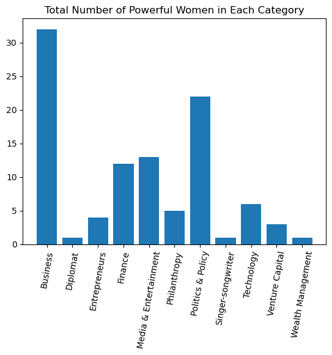

```python
# Bar chart showing the category that has the most powerful women in the world

plot_df=df_updated.groupby(['CATEGORY']).count().sort_values(['NAME'],ascending=False)
plot_df=plot_df.sort_values('CATEGORY').reset_index()
x=plot_df['CATEGORY'].astype(str)
y=plot_df['NAME']
plt.bar(x, height=y, width=0.8)
plt.title("Total Number of Powerful Women in Each Category")
plt.xticks(rotation=80);
```

- Business category has the most powerful women in the world
- That is most of the powerful women in the world are business women or into business
- Politics and policy is also stacked with a lot of powerful women after business category being first. This shows that women are diving more into politics
- Singing, Wealth management and Diplomat had the lowest amount of powerful women in the top 100 most powerful women in the world

##### QUESTION 4: THE COUNTRY WITH THE MOST POWERFUL WOMEN

```python
# Here I will be looking for the country with the most powerful women in the list
df_country = df_updated.groupby(['LOCATION','NAME']).size().groupby('LOCATION').count()
```

```python
df_country
```

```
LOCATION
Australia                4
Bangladesh               1
Barbados                 1
Belgium                  1
China                    5
Denmark                  1
Finland                  1
France                   3
Germany                  3
Honduras                 1
India                    6
Indonesia                2
Iran                     1
Italy                    1
Japan                    2
Mexico                   1
New Zealand              1
Nigeria                  2
Singapore                2
Slovakia                 1
South Korea              1
Spain                    1
Taiwan                   1
Tanzania                 1
Turkey                   1
United Arab Emirates     2
United Kingdom           3
United States           50
dtype: int64
```

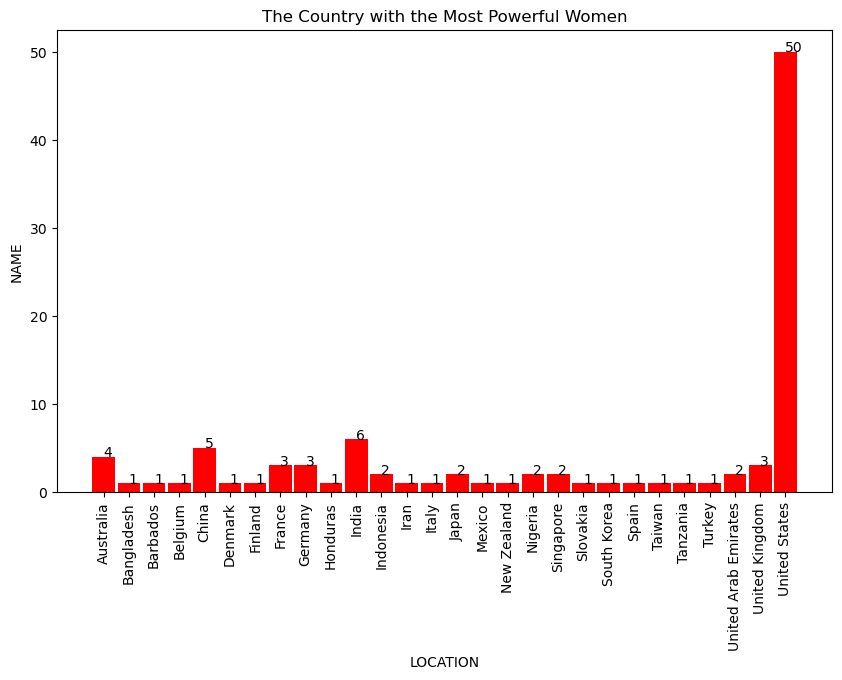

```python
# Bar chart showing the country with the most powerful women
def addlabels(x,y):  #function to add value labels
    for i in range(len(x)):
        plt.text(i,y[i],y[i])

fig, ax = plt.subplots(figsize=(10, 6))
plot_df=df_updated.groupby(['LOCATION']).count().sort_values(['NAME'],ascending=False)
plot_df=plot_df.sort_values('LOCATION').reset_index()
x=plot_df['LOCATION'].astype(str)
y=plot_df['NAME']
plt.bar(x, height=y, width=0.9, color='red')   #making the bar chart

# calling the function to add value labels
addlabels(x, y)

plt.title("The Country with the Most Powerful Women")

# giving X and Y labels
plt.xlabel("LOCATION")
plt.ylabel("NAME")

plt.xticks(rotation=90);

plt.show() #visualizing the plot
```

- The United States is the country with the most powerful women and this shows how women rights, involvement in politics and policy making, equality, women in business and other sectors has grown positively in the united States
- The United States had a very high volume of powerful women with about 50% of the women coming from the country compared to other countries
- India was the second country with the most powerful women in the world with very low numbers compared to the United States

##### QUESTION 5: THE MOST POWERFUL WOMEN FROM NORTH AMERICA

```python
# Finding the most powerful women from North America
north_america = (df_updated['CONTINENT'].isin(['North America']).groupby(df_updated['NAME']).transform('any'))
df_updated.loc[north_america]
north_america1 = df_updated.loc[north_america]
north_america1
```

|  | RANK | NAME | AGE | LOCATION | CATEGORY | CONTINENT |
| --- | --- | --- | --- | --- | --- | --- |
| 2 | 3.0 | Kamala Harris | 58 | United States | Politics & Policy | North America |
| 3 | 4.0 | Mary Barra | 60 | United States | Business | North America |
| 4 | 5.0 | Abigail Johnson | 60 | United States | Business | North America |
| 5 | 6.0 | Melinda French Gates | 58 | United States | Philanthropy | North America |
| 7 | 8.0 | Karen Lynch | 58 | United States | Business | North America |
| 8 | 9.0 | Julie Sweet | 55 | United States | Business | North America |
| 9 | 10.0 | Jane Fraser | 55 | United States | Finance | North America |
| 10 | 11.0 | MacKenzie Scott | 52 | United States | Philanthropy | North America |
| 11 | 12.0 | Kristalina Georgieva | 69 | United States | Politics & Policy | North America |
| 12 | 13.0 | Rosalind Brewer | 59 | United States | Business | North America |
| 15 | 16.0 | Gail Boudreaux | 62 | United States | Business | North America |
| 17 | 18.0 | Ruth Porat | 65 | United States | Technology | North America |
| 18 | 19.0 | Safra Catz | 60 | United States | Technology | North America |
| 20 | 21.0 | Carol Tomé | 65 | United States | Business | North America |
| 21 | 22.0 | Judith McKenna | 56 | United States | Business | North America |
| 22 | 23.0 | Susan Wojcicki | 54 | United States | Technology | North America |
| 23 | 24.0 | Oprah Winfrey | 68 | United States | Media & Entertainment | North America |
| 24 | 25.0 | Nancy Pelosi | 82 | United States | Politics & Policy | North America |
| 25 | 26.0 | Laurene Powell Jobs & family | 59 | United States | Philanthropy | North America |
| 27 | 28.0 | Amy Hood | 50 | United States | Technology | North America |
| 29 | 30.0 | Phebe Novakovic | 65 | United States | Entrepreneurs | North America |
| 30 | 31.0 | Gwynne Shotwell | 59 | United States | Technology | North America |
| 31 | 32.0 | Shari Redstone | 68 | United States | Media & Entertainment | North America |
| 32 | 33.0 | Janet Yellen | 76 | United States | Politics & Policy | North America |
| 36 | 37.0 | Thasunda Brown Duckett | 49 | United States | Finance | North America |
| 37 | 38.0 | Kathy Warden | 51 | United States | Business | North America |
| 38 | 39.0 | Marianne Lake, Jennifer Piepszak(52_years) | 54 | United States | Finance | North America |
| 40 | 41.0 | Dana Walden | 58 | United States | Media & Entertainment | North America |
| 42 | 43.0 | Mary Callahan Erdoes | 55 | United States | Wealth Management | North America |
| 43 | 44.0 | Adena Friedman | 53 | United States | Finance | North America |
| 45 | 46.0 | Lynn Martin | 46 | United States | Finance | North America |
| 47 | 48.0 | Vicki Hollub | 63 | United States | Entrepreneurs | North America |
| 49 | 50.0 | Lisa Su | 53 | United States | Entrepreneurs | North America |
| 50 | 51.0 | Tricia Griffith | 58 | United States | Business | North America |
| 57 | 58.0 | Jennifer Salke | 58 | United States | Media & Entertainment | North America |
| 58 | 59.0 | Jenny Johnson | 58 | United States | Business | North America |
| 60 | 61.0 | Donna Langley | 54 | United States | Media & Entertainment | North America |
| 62 | 63.0 | Judy Faulkner | 79 | United States | Entrepreneurs | North America |
| 64 | 65.0 | Suzanne Scott | 56 | United States | Media & Entertainment | North America |
| 65 | 66.0 | Lynn Good | 63 | United States | Business | North America |
| 69 | 70.0 | Bela Bajaria | 51 | United States | Media & Entertainment | North America |
| 70 | 71.0 | Paula Santilli | 57 | Mexico | Business | North America |
| 72 | 73.0 | Rihanna | 34 | United States | Media & Entertainment | North America |
| 74 | 75.0 | Mary Meeker | 63 | United States | Venture Capital | North America |
| 78 | 79.0 | Taylor Swift | 32 | United States | Media & Entertainment | North America |
| 79 | 80.0 | Beyoncé Knowles | 41 | United States | Media & Entertainment | North America |
| 81 | 82.0 | Linda Thomas-Greenfield | 70 | United States | Diplomat | North America |
| 85 | 86.0 | Reese Witherspoon | 46 | United States | Media & Entertainment | North America |
| 92 | 93.0 | Shonda Rhimes | 52 | United States | Media & Entertainment | North America |
| 93 | 94.0 | Xiomara Castro | 63 | Honduras | Politics & Policy | North America |
| 95 | 96.0 | Dolly Parton | 76 | United States | Singer-songwriter | North America |
| 96 | 97.0 | Kirsten Green | 51 | United States | Venture Capital | North America |
| 97 | 98.0 | Mia Mottley | 57 | Barbados | Politics & Policy | North America |

- The most powerful woman from North America is Kamala Harris, who is a politician and the current vice president of the United States of America
- North America is the continent with the most powerful women on earth
- Taylor Swift is the youngest most powerful woman from North America

##### QUESTION 6: THE MOST POWERFUL WOMEN FROM AFRICA

```python
# Finding the most powerful women from Africa
africa = (df_updated['CONTINENT'].isin(['Africa']).groupby(df_updated['NAME']).transform('any'))
df_updated.loc[africa]
africa1 = df_updated.loc[africa]
africa1.head()
```

|  | RANK | NAME | AGE | LOCATION | CATEGORY | CONTINENT |
| --- | --- | --- | --- | --- | --- | --- |
| 90 | 91.0 | Ngozi Okonjo-Iweala | 68 | Nigeria | Politics & Policy | Africa |
| 94 | 95.0 | Samia Suluhu Hassan | 62 | Tanzania | Politics & Policy | Africa |
| 98 | 99.0 | Mo Abudu | 58 | Nigeria | Media & Entertainment | Africa |

- Nigeria has the most powerful women from Africa on the list of top 100 most powerful women in the world
- Only 2 African countries and 3 Africans are part of the 100 most powerful women in the world
- Ngozi Okonjo-Iweala is the most powerful woman from Africa
- Samia Suluhu Hassan a Tanzanian politician is the 2nd most powerful woman in Africa and one of the 3 women from Africa who made it to the top 100 list of the most powerful women in the world
- Mo Abudu is the 3rd most powerful woman in Africa and one of the only two women from Nigeria who made the top 100 list of the most powerful women in the world

##### QUESTION 7: THE MOST POWERFUL WOMEN FROM ASIA

```python
# Finding the most powerful women from Asia
asia = (df_updated['CONTINENT'].isin(['Asia']).groupby(df_updated['NAME']).transform('any'))
df_updated.loc[asia]
asia1 = df_updated.loc[asia]
asia1
```

|  | RANK | NAME | AGE | LOCATION | CATEGORY | CONTINENT |
| --- | --- | --- | --- | --- | --- | --- |
| 16 | 17.0 | Tsai Ing-wen | 66 | Taiwan | Politics & Policy | Asia |
| 33 | 34.0 | Jessica Tan | 45 | China | Finance | Asia |
| 34 | 35.0 | Ho Ching | 69 | Singapore | Finance | Asia |
| 35 | 36.0 | Nirmala Sitharaman | 63 | India | Politics & Policy | Asia |
| 41 | 42.0 | Sheikh Hasina Wajed | 75 | Bangladesh | Politics & Policy | Asia |
| 46 | 47.0 | Sri Mulyani Indrawati | 60 | Indonesia | Politics & Policy | Asia |
| 48 | 49.0 | Nicke Widyawati | 54 | Indonesia | Business | Asia |
| 52 | 53.0 | Roshni Nadar Malhotra | 41 | India | Technology | Asia |
| 53 | 54.0 | Madhabi Puri Buch | 56 | India | Politics & Policy | Asia |
| 55 | 56.0 | Tokiko Shimizu | 57 | Japan | Finance | Asia |
| 56 | 57.0 | Yuriko Koike | 70 | Japan | Politics & Policy | Asia |
| 59 | 60.0 | Hana Al Rostamani |  | United Arab Emirates | Finance | Asia |
| 61 | 62.0 | Dong Mingzhu | 68 | China | Business | Asia |
| 66 | 67.0 | Soma Mondal | 59 | India | Business | Asia |
| 71 | 72.0 | Laura Cha | 73 | China | Finance | Asia |
| 75 | 76.0 | Joey Wat | 51 | China | Business | Asia |
| 76 | 77.0 | Kiran Mazumdar-Shaw | 69 | India | Business | Asia |
| 77 | 78.0 | Jenny Lee | 50 | Singapore | Venture Capital | Asia |
| 83 | 84.0 | Solina Chau | 60 | China | Philanthropy | Asia |
| 84 | 85.0 | Lee Boo-jin | 52 | South Korea | Business | Asia |
| 88 | 89.0 | Falguni Nayar | 59 | India | Business | Asia |
| 91 | 92.0 | Raja Easa Al Gurg | 67 | United Arab Emirates | Business | Asia |
| 99 | 100.0 | Mahsa Amini (posthumous) | 22 | Iran | Politics & Policy | Asia |

- Tsai Ing-wen a Taiwanese politician is the most powerful woman from Asia and the 17th in the world
- Mahsa Amini (posthumous) the Iranian lady who died late last year is the youngest most powerful woman from Asia and the only woman from Iran to make the list of the top 100 most powerful women in the world

##### QUESTION 8: MOST POWERFUL WOMEN FROM EUROPE

```python
# Finding the most powerful women from Europe
europe = (df_updated['CONTINENT'].isin(['Europe']).groupby(df_updated['NAME']).transform('any'))
df_updated.loc[europe]
europe1 = df_updated.loc[europe]
europe1
```

|  | RANK | NAME | AGE | LOCATION | CATEGORY | CONTINENT |
| --- | --- | --- | --- | --- | --- | --- |
| 0 | 1.0 | Ursula von der Leyen | 64 | Belgium | Politics & Policy | Europe |
| 1 | 2.0 | Christine Lagarde | 66 | France | Politics & Policy | Europe |
| 6 | 7.0 | Giorgia Meloni | 45 | Italy | Politics & Policy | Europe |
| 13 | 14.0 | Emma Walmsley | 53 | United Kingdom | Business | Europe |
| 14 | 15.0 | Ana Patricia Botín | 62 | Spain | Finance | Europe |
| 19 | 20.0 | Martina Merz | 59 | Germany | Business | Europe |
| 26 | 27.0 | Amanda Blanc | 55 | United Kingdom | Business | Europe |
| 28 | 29.0 | Catherine MacGregor | 50 | France | Business | Europe |
| 54 | 55.0 | Sinead Gorman | 45 | United Kingdom | Business | Europe |
| 67 | 68.0 | Belén Garijo | 62 | Germany | Business | Europe |
| 68 | 69.0 | Melanie Kreis | 51 | Germany | Business | Europe |
| 73 | 74.0 | Mette Frederiksen | 45 | Denmark | Politics & Policy | Europe |
| 80 | 81.0 | Güler Sabanci | 67 | Turkey | Business | Europe |
| 82 | 83.0 | Sanna Marin | 37 | Finland | Politics & Policy | Europe |
| 86 | 87.0 | Zuzana Caputova | 49 | Slovakia | Politics & Policy | Europe |
| 87 | 88.0 | Dominique Senequier | 69 | France | Finance | Europe |

- Ursula von der Leyen the most powerful woman in the world topped the list as the most powerful woman from Europe
- Sanna Marin a Finnish politician is the youngest most powerful woman from Europe

##### QUESTION 9: MOST POWERFUL WOMEN FROM AUSTRALIA

```python
# Finding the most powerful women from Australia
australia = (df_updated['CONTINENT'].isin(['Australia']).groupby(df_updated['NAME']).transform('any'))
df_updated.loc[australia]
australia1 = df_updated.loc[australia]
australia1
```

|  | RANK | NAME | AGE | LOCATION | CATEGORY | CONTINENT |
| --- | --- | --- | --- | --- | --- | --- |
| 39 | 40.0 | Jacinda Ardern | 42 | New Zealand | Politics & Policy | Australia |
| 44 | 45.0 | Gina Rinehart | 68 | Australia | Business | Australia |
| 51 | 52.0 | Shemara Wikramanayake | 60 | Australia | Business | Australia |
| 63 | 64.0 | Robyn Denholm | 59 | Australia | Business | Australia |
| 89 | 90.0 | Julia Gillard | 61 | Australia | Philanthropy | Australia |

- Jacinda Ardern the 40th Prime Minister of New Zealand is the most powerful woman from the Australian continent
- Jacinda Ardern is the only woman from New Zealand to make it to top the 100 list of the most powerful women in the world
- Australia as a country has the most powerful women from the Australian continent
- Gina Rinehart an Australian mining magnate and businesswoman is the second most powerful woman from the Australian continent and the most powerful woman from Australia as a country

##### QUESTION 10: THE CONTINENT WITH THE MOST POWERFUL WOMEN

In terms of the top 100 most powerful women list, I will be looking for the continent with the most powerful women

```python
# Here I will be looking for the continent with the most powerful women out of the top 100 list of powerful women in the world
df_continent = df_updated.groupby(['CONTINENT','NAME']).size().groupby('CONTINENT').count()
```

```python
df_continent
```

```
CONTINENT
Africa            3
Asia             23
Australia         5
Europe           16
North America    53
dtype: int64
```

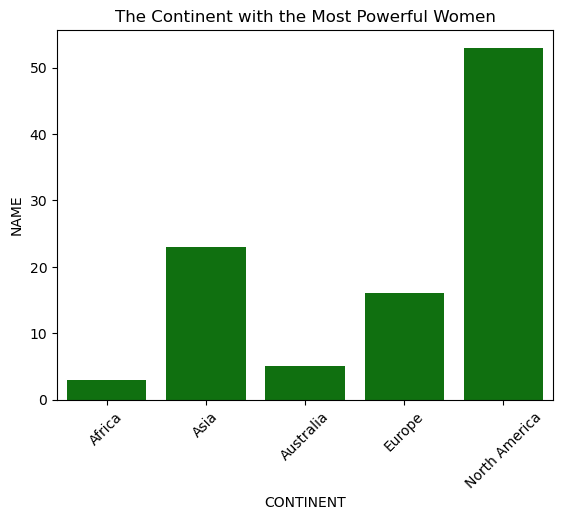

```python
# Using a barplot to show the continent with the most powerful women in the top 100 list
color = ['green']
plot_df1=df_updated.groupby(['CONTINENT']).count().sort_values(['NAME'],ascending=False)
plot_df1=plot_df1.sort_values('CONTINENT').reset_index()
ax = sns.barplot(x=plot_df1['CONTINENT'].astype(str), y=plot_df1['NAME'], data=plot_df1, palette=color)
ax.set_title("The Continent with the Most Powerful Women")
plt.xticks(rotation=45);
```

Using a pie chart to show the percentage each continent represents in the top 100 most powerful women list

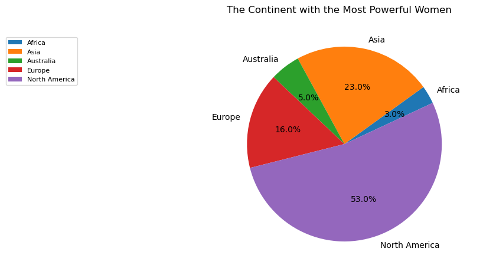

```python
# Using a pie chart to show the percentage each continent represents in the top 100 most powerful women list

my_data = (plot_df1['NAME'])
my_labels = (plot_df1['CONTINENT'])
plt.pie(my_data, labels=my_labels, startangle=25, autopct='%1.1f%%')
plt.suptitle('The Continent with the Most Powerful Women')
plt.axis('equal')
plt.legend(my_labels, loc='best', bbox_to_anchor=(-0.4, 1), fontsize=8)
plt.show()
```

- Here we can see that North America has 53 out of the 100 most powerful women in the world, making them the continent with the most amount of powerful women in the world
- Africa and Australia had the lowest with Africa having 3 powerful women and Australia having only 5 powerful women
- Asia is the second continent with more powerful women in the list after North America with total of 23 powerful women in the world
- Europe had about 16 most powerful women in the list

##### QUESTION 11: MOST POWERFUL WOMEN UNDER THE AGE OF 50

```python
# Before running the code for the most powerful women under age 50, I have to convert the age values to numeric values, so that the code can run
df_updated['AGE'] = pd.to_numeric(df_updated['AGE'])
```

```python
# Finding the most powerful women under age 50
df_under_50 = df_updated.loc[df_updated['AGE']<50]
df_under_50
```

|  | RANK | NAME | AGE | LOCATION | CATEGORY | CONTINENT |
| --- | --- | --- | --- | --- | --- | --- |
| 6 | 7.0 | Giorgia Meloni | 45.0 | Italy | Politics & Policy | Europe |
| 33 | 34.0 | Jessica Tan | 45.0 | China | Finance | Asia |
| 36 | 37.0 | Thasunda Brown Duckett | 49.0 | United States | Finance | North America |
| 39 | 40.0 | Jacinda Ardern | 42.0 | New Zealand | Politics & Policy | Australia |
| 45 | 46.0 | Lynn Martin | 46.0 | United States | Finance | North America |
| 52 | 53.0 | Roshni Nadar Malhotra | 41.0 | India | Technology | Asia |
| 54 | 55.0 | Sinead Gorman | 45.0 | United Kingdom | Business | Europe |
| 72 | 73.0 | Rihanna | 34.0 | United States | Media & Entertainment | North America |
| 73 | 74.0 | Mette Frederiksen | 45.0 | Denmark | Politics & Policy | Europe |
| 78 | 79.0 | Taylor Swift | 32.0 | United States | Media & Entertainment | North America |
| 79 | 80.0 | Beyoncé Knowles | 41.0 | United States | Media & Entertainment | North America |
| 82 | 83.0 | Sanna Marin | 37.0 | Finland | Politics & Policy | Europe |
| 85 | 86.0 | Reese Witherspoon | 46.0 | United States | Media & Entertainment | North America |
| 86 | 87.0 | Zuzana Caputova | 49.0 | Slovakia | Politics & Policy | Europe |
| 99 | 100.0 | Mahsa Amini (posthumous) | 22.0 | Iran | Politics & Policy | Asia |

##### QUESTION 12: YOUNGEST MOST POWERFUL WOMEN

Here I will be visualizing the youngest most powerful women in the world. I will use the data from the most powerful women under the age of 50 to find and visualize the youngest powerful women on earth.

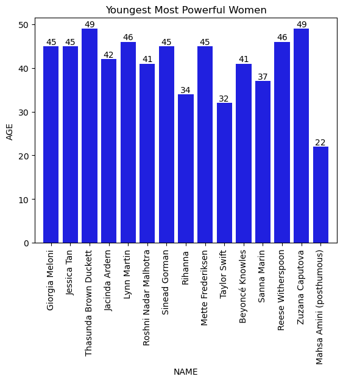

```python
# Youngest most powerful women in the world

ax = sns.barplot(x='NAME', y='AGE', data=df_under_50, color='blue')
ax.set_title("Youngest Most Powerful Women")
ax.margins(x=0.03)
ax.bar_label(ax.containers[0])
plt.xticks(rotation=90);
```

- Mahsa Amini (posthumous) who is late is the youngest most powerful woman in the world. She was 22 at the time of her death and appeared on the list of the most powerful women on earth
- Taylor Swift the American entertainment star and musician came as the second youngest most powerful wooman on earth. She is just 32 years old